```python
import statsmodels.api as sm
import pandas as pd
from pandas import DataFrame, Series
import numpy as np
import matplotlib.pyplot as plt
import scipy.stats as stats
import datetime
import time
import json
import re
import scipy
from dateutil.relativedelta import relativedelta
import matplotlib.font_manager as fm

pd.set_option('display.max_columns', 100)
pd.set_option('display.width', 5000)

import psycopg2
from pymongo import MongoClient
```

# Series

```python
series = pd.read_csv('../notebook/BD_시계열_20221019.csv')

series_2 = pd.read_csv('../notebook/BD_시계열_20220401.csv')

series_3 = pd.read_csv('../notebook/BD_시계열_20210601.csv')

series_4 = pd.read_csv('../notebook/BD_시계열_20210201.csv')

series_5 = pd.read_csv('../notebook/BD_시계열_20201001.csv')
```

```python
series = pd.concat([series_5,
                    pd.concat([series_4,
                            pd.concat([series_3,
                                        pd.concat([series_2,
                                                    series],
                                                  axis = 0)],
                                       axis = 0)],
                           axis = 0)],
                  axis = 0).reset_index(drop = True)
```

```python
def min_max_scailing(x, max_value = None, min_value = None):
    if max_value is None:
        max_value = x.max()
    if min_value is None:
        min_value = x.min()

    return (x - min_value) / (max_value - min_value)
```

```python
fit_line = np.polyfit(series['totalOrder'],
           [i for i in range(0, len(series))],
           2)
```

```python
years = 2
```

```python
for i in range(0, years):
    if i == 0:
        spl_tol = scipy.interpolate.UnivariateSpline(
                                [i for i in range(0, round(len(series) / years))],
                                min_max_scailing(series['totalOrder'][
                                    0 : round(len(series) / years)],
                                                max_value = series['totalOrder'].max(),
                                                min_value = series['totalOrder'].min()),
                                k = 5)
        tol_array = spl_tol([i for i in range(0, round(len(series) / years))])
    else:
        spl_tol = scipy.interpolate.UnivariateSpline(
                        [i for i in range(i * round(len(series) / years),
                                          (i + 1) * round(len(series) / years))],
                        min_max_scailing(series['totalOrder'][
                                    i * round(len(series) / years) :
                                    (i + 1) * round(len(series) / years)],
                                                max_value = series['totalOrder'].max(),
                                                min_value = series['totalOrder'].min()
                        ),
                        k = 5)
        temp = spl_tol([i for i in range(i * round(len(series) / years),
                                          (i + 1) * round(len(series) / years))])

        tol_array = np.concatenate([tol_array, temp])
```

```python
for i in range(0, years):
    if i == 0:
        spl_sku = scipy.interpolate.UnivariateSpline(
                                [i for i in range(0, round(len(series) / years))],
                                min_max_scailing(series['cumSKU'][
                                    0 : round(len(series) / years)],
                                                max_value = series['cumSKU'].max(),
                                                min_value = series['cumSKU'].min()),
                                k = 5)
        sku_array = spl_sku([i for i in range(0, round(len(series) / years))])
    else:
        spl_sku = scipy.interpolate.UnivariateSpline(
                        [i for i in range(i * round(len(series) / years),
                                          (i + 1) * round(len(series) / years))],
                        min_max_scailing(series['cumSKU'][
                                    i * round(len(series) / years) :
                                    (i + 1) * round(len(series) / years)],
                                                max_value = series['cumSKU'].max(),
                                                min_value = series['cumSKU'].min()
                        ),
                        k = 5)
        temp = spl_sku([i for i in range(i * round(len(series) / years),
                                          (i + 1) * round(len(series) / years))])

        sku_array = np.concatenate([sku_array, temp])
```

```python
date = series['date'].iloc[::5]
```

```python
font_location = 'C:/Windows/Fonts/gulim.ttc' # For Windows
font_name = fm.FontProperties(fname=font_location).get_name()
plt.rc('font', family=font_name)
```

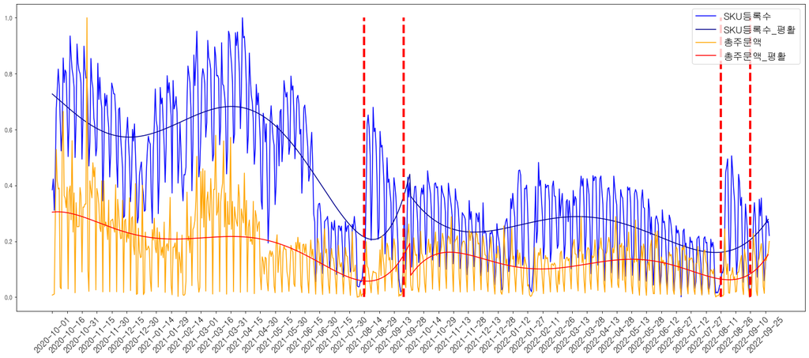

```python
plt.figure(figsize = (25,10))
plt.plot(min_max_scailing(series['cumSKU']), label = 'SKU등록수', color = 'blue')
plt.plot(sku_array, label = 'SKU등록수_평활', color = 'darkblue')
plt.plot(min_max_scailing(series['totalOrder']), label = '총주문액', color = 'orange')
plt.plot(tol_array, label = '총주문액_평활', color = 'red')
plt.xticks([i for i in range(0, len(series), 15)], series['date'].iloc[::15],
           rotation = 45, fontsize = 'x-large')
plt.vlines(x = int(date[date == '2022-09-10'].index.values),
           ymin = 0 , ymax = 1, color = 'red', linestyles='--', linewidth = 4)
plt.vlines(x = int(date[date == '2022-08-11'].index.values),
           ymin = 0 , ymax = 1, color = 'red', linestyles='--', linewidth = 4)
plt.vlines(x = int(date[date == '2021-09-23'].index.values),
           ymin = 0 , ymax = 1, color = 'red', linestyles='--', linewidth = 4)
plt.vlines(x = int(date[date == '2021-08-14'].index.values),
           ymin = 0 , ymax = 1, color = 'red', linestyles='--', linewidth = 4)
plt.legend(fontsize = 'xx-large', loc = 1)
plt.show()
```

```python
plt.figure(figsize = (25,10))
plt.plot(min_max_scailing(series['cumSKU']), label = 'SKU등록수', color = 'blue')
plt.plot(sku_array, label = 'SKU등록수_평활', color = 'darkblue')
plt.plot(min_max_scailing(series['totalOrder']), label = '총주문액', color = 'orange')
plt.plot(tol_array, label = '총주문액_평활', color = 'red')
plt.xticks([i for i in range(0, len(series), 15)], series['date'].iloc[::15],
           rotation = 45, fontsize = 'x-large')
plt.vlines(x = int(date[date == '2022-09-10'].index.values),
           ymin = 0 , ymax = 1, color = 'red', linestyles='--', linewidth = 4)
plt.vlines(x = int(date[date == '2022-08-11'].index.values),
           ymin = 0 , ymax = 1, color = 'red', linestyles='--', linewidth = 4)
plt.vlines(x = int(date[date == '2021-09-23'].index.values),
           ymin = 0 , ymax = 1, color = 'red', linestyles='--', linewidth = 4)
plt.vlines(x = int(date[date == '2021-08-14'].index.values),
           ymin = 0 , ymax = 1, color = 'red', linestyles='--', linewidth = 4)
plt.legend(fontsize = 'xx-large', loc = 1)
plt.show()
```

```python
plt.figure(figsize = (20,10))

plt.xticks([i for i in range(0, len(series), 5)], series['date'].iloc[::5], rotation = 45)
plt.show()
```

# OrderSeries

```python
client = MongoClient(host='10.10.224.28',
                     port=27017,
                     username='vida',
                     password='qwer123$')

db_datamart = client['datamart']
```

```python
dataframe_orderseries = pd.concat([pd.read_csv('./BD/BD_주문시계열_20201001_20210331.csv'),
           pd.concat([pd.read_csv('./BD/BD_주문시계열_20210401_20210930.csv'),
                     pd.concat([pd.read_csv('./BD/BD_주문시계열_20211001_20220331.csv'),
                               pd.read_csv('./BD/BD_주문시계열_20220401_20220930.csv')])])]).reset_index(drop = True)
```

## 국가별 주문액 시계열

### 가설 설정

다음의 가설을 분석한다.

- 글로벌멤버십의 증감은 실제 주문액의 증감에 영향을 미치고 있을 것이다

위 가설을 검정하기 위해 계량경제학에서 사용하는 방법론인 충격반응함수(RIF) 분석을 시도한다.

```python
def min_max_scailing(x, max_value = None, min_value = None):
    if max_value is None:
        max_value = x.max()
    if min_value is None:
        min_value = x.min()

    return (x - min_value) / (max_value - min_value)
```

```python
dataframe_orderseries['date'] = dataframe_orderseries['createdAt'].astype('datetime64').dt.date

dataframe_orderseries_country = dataframe_orderseries.copy()

dataframe_orderseries_country['isKR'] = dataframe_orderseries_country['countryCode'] == 'KR'

dataframe_orderseries_country = dataframe_orderseries_country.groupby(['date','isKR'])['initTotalKRW'].sum()

dataframe_orderseries_country = dataframe_orderseries_country.reset_index()

years = 2

kr_total = dataframe_orderseries_country[dataframe_orderseries_country['isKR']]['initTotalKRW'].reset_index(drop = True)
foreign_total = dataframe_orderseries_country[dataframe_orderseries_country['isKR'] == False]['initTotalKRW'].reset_index(drop = True)
```

```python
for i in range(0, years):
    if i == 0:
        spl_sku = scipy.interpolate.UnivariateSpline(
                                [i for i in range(0, round(len(kr_total) / years))],
                                min_max_scailing(kr_total[
                                    0 : round(len(kr_total) / years)],
                                                max_value = kr_total.max(),
                                                min_value = kr_total.min()),
                                k = 5)
        sku_array = spl_sku([i for i in range(0, round(len(kr_total) / years))])
    else:
        spl_sku = scipy.interpolate.UnivariateSpline(
                        [i for i in range(i * round(len(kr_total) / years),
                                          (i + 1) * round(len(kr_total) / years) - 1)],
                        min_max_scailing(kr_total[
                                    i * round(len(kr_total) / years) :
                                    (i + 1) * round(len(kr_total) / years)],
                                                max_value = kr_total.max(),
                                                min_value = kr_total.min()
                        ),
                        k = 5)
        temp = spl_sku([i for i in range(i * round(len(kr_total) / years),
                                          (i + 1) * round(len(kr_total) / years))])

        sku_array = np.concatenate([sku_array, temp])
```

```python
for i in range(0, years):
    if i == 0:
        spl_sku = scipy.interpolate.UnivariateSpline(
                                [i for i in range(0, round(len(foreign_total) / years))],
                                min_max_scailing(foreign_total[
                                    0 : round(len(foreign_total) / years)],
                                                max_value = foreign_total.max(),
                                                min_value = foreign_total.min()),
                                k = 5)
        tol_array = spl_sku([i for i in range(0, round(len(foreign_total) / years))])
    else:
        spl_sku = scipy.interpolate.UnivariateSpline(
                        [i for i in range(i * round(len(foreign_total) / years),
                                          (i + 1) * round(len(foreign_total) / years) - 1)],
                        min_max_scailing(foreign_total[
                                    i * round(len(foreign_total) / years) :
                                    (i + 1) * round(len(foreign_total) / years)],
                                                max_value = foreign_total.max(),
                                                min_value = foreign_total.min()
                        ),
                        k = 5)
        temp = spl_sku([i for i in range(i * round(len(foreign_total) / years),
                                          (i + 1) * round(len(foreign_total) / years))])

        tol_array = np.concatenate([tol_array, temp])
```

```python
import matplotlib
import matplotlib.font_manager as fm
fm.get_fontconfig_fonts()
font_location = 'C:/Windows/Fonts/gulim.ttc' # For Windows
font_name = fm.FontProperties(fname=font_location).get_name()
matplotlib.rc('font', family=font_name)
```

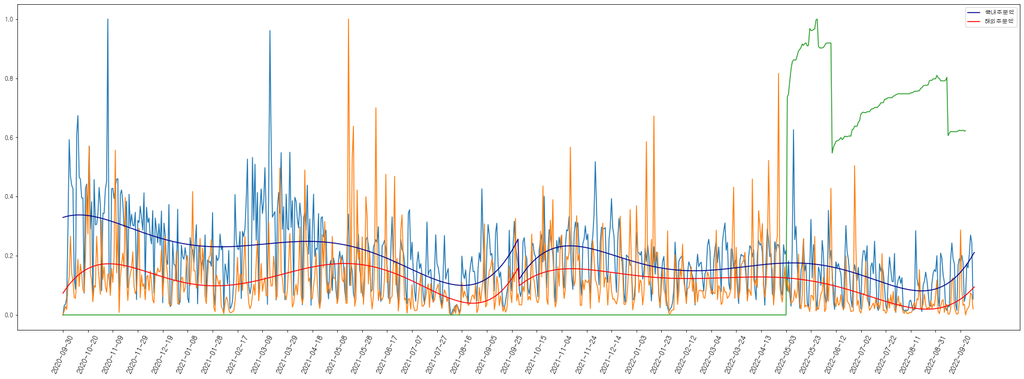

```python
plt.figure(figsize = (30,10))
plt.plot(min_max_scailing(kr_total))
plt.plot(min_max_scailing(foreign_total))
plt.plot(min_max_scailing(series['currentActive']))
plt.plot(sku_array, label = '국내주문액', color = 'darkblue')
plt.plot(tol_array, label = '해외주문액', color = 'red')
plt.xticks([i for i in range(0, len(kr_total),20)],
           dataframe_orderseries_country[dataframe_orderseries_country['isKR']]['date'].reset_index(drop = True).iloc[::20],
           rotation = 65, fontsize = 'large')
plt.legend()
plt.show()
```

```python
decomp = sm.tsa.STL(foreign_total, period = 7).fit()
```

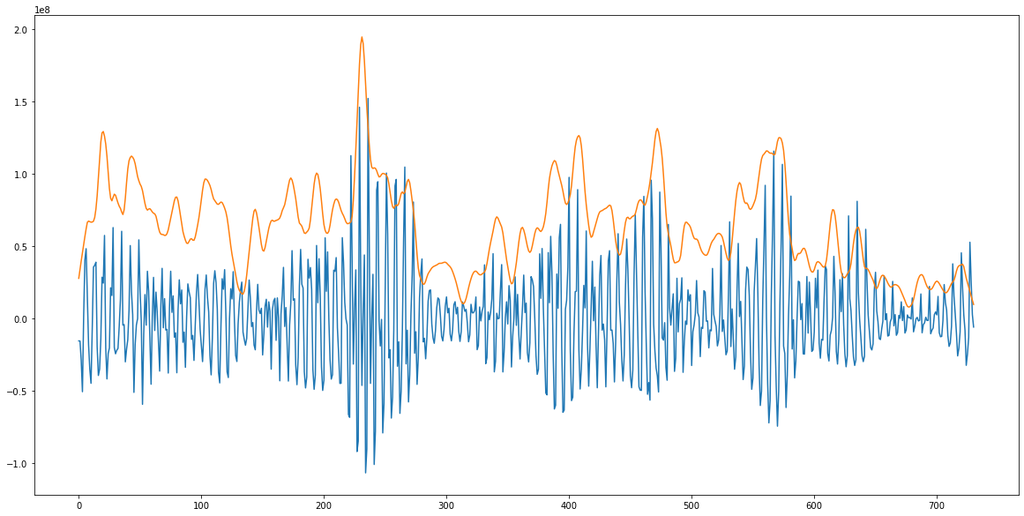

```python
plt.figure(figsize = (20, 10))
plt.plot(decomp.seasonal)
plt.plot(decomp.trend)
```

- 7일(1주) 단위 주기를 통제했다.

```python
decomp = sm.tsa.STL(decomp.trend.fillna(0), period = 365).fit()
```

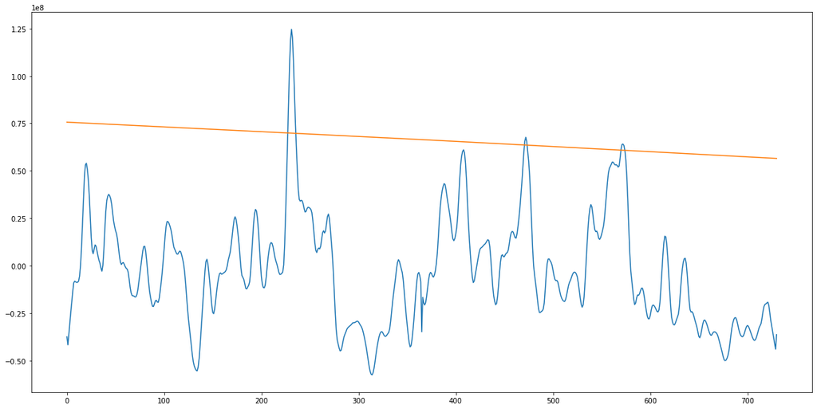

```python
plt.figure(figsize = (20,10))
plt.plot(decomp.seasonal)
plt.plot(decomp.trend)
```

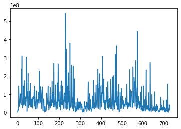

```python
plt.plot(foreign_total)
```

- 다시, 1년 단위로 반복하는 주기를 통제한다.
- 추세선은 전반적으로 우하향이다.

### 충격반응분석

```python
dataframe_orderseries['date'] = dataframe_orderseries['createdAt'].astype('datetime64').dt.date

dataframe_orderseries_country = dataframe_orderseries.copy()

dataframe_orderseries_country['isKR'] = dataframe_orderseries_country['countryCode'] == 'KR'

dataframe_orderseries_country = dataframe_orderseries_country.groupby(['date','isKR'])['initTotalKRW'].sum()

dataframe_orderseries_country = dataframe_orderseries_country.reset_index()

years = 2

kr_total = dataframe_orderseries_country[dataframe_orderseries_country['isKR']]['initTotalKRW'].reset_index(drop = True)
foreign_total = dataframe_orderseries_country[dataframe_orderseries_country['isKR'] == False]['initTotalKRW'].reset_index(drop = True)
```

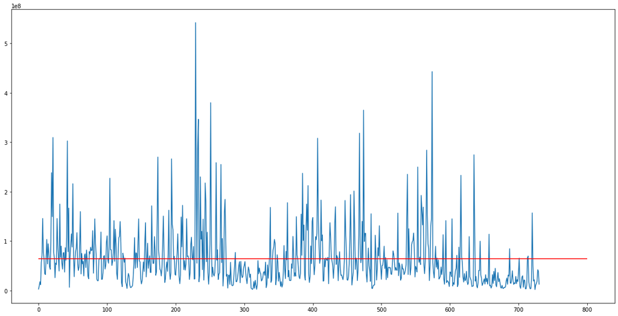

```python
plt.figure(figsize = (20,10))
plt.plot(foreign_total)
plt.hlines(foreign_total.mean(), xmin = 0, xmax = 800, color = 'red')
```

#### - ADF 단위근 검정

```python
sm.tsa.stattools.adfuller(foreign_total)[1]
```

```
0.04644317179583582
```

a = 0.05일때 p-value는 0.04로서 단위근이 존재한다는 귀무가설을 기각 가능하다.(다행스)

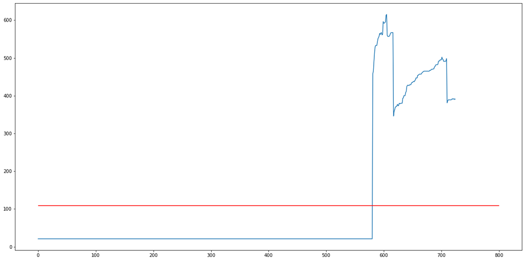

```python
plt.figure(figsize = (20,10))
plt.plot(series['currentActive'])
plt.hlines(series['currentActive'].mean(), xmin = 0, xmax = 800, color = 'red')
```

```python
sm.tsa.stattools.adfuller(series['currentActive'])[1]
```

```
0.7421778510757218
```

- 당연하게도 단위근이 있는 것으로 나온다.
- 차분을 실시하여 단위근을 제거한다.

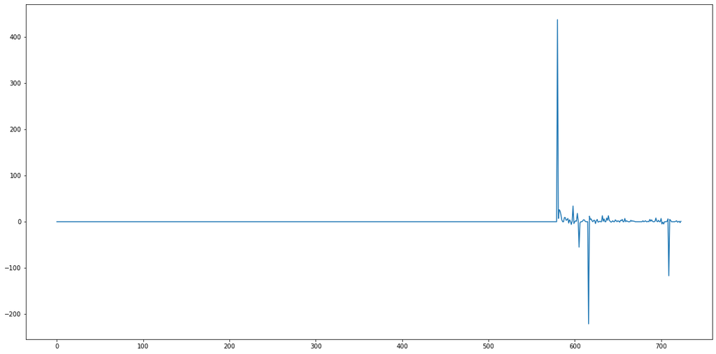

```python
plt.figure(figsize = (20,10))
plt.plot(np.diff(series['currentActive']))
```

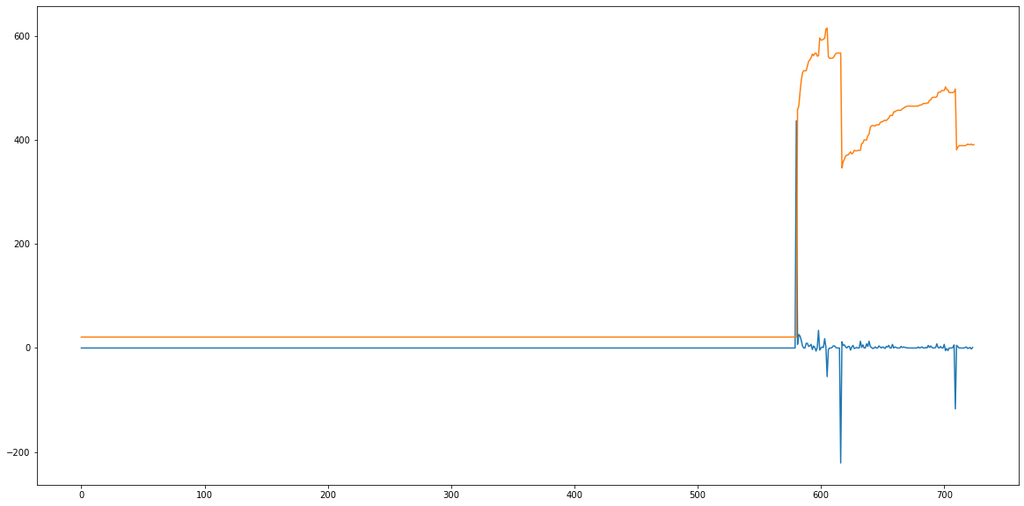

```python
plt.figure(figsize = (20,10))
plt.plot(Series(np.diff(series['currentActive'])))
plt.plot(series['currentActive'])
```

```python
diff_values = np.diff(series['currentActive']).tolist()
```

```python
diff_values.insert(0, 0)
```

```python
sm.tsa.stattools.adfuller(np.diff(series['currentActive']))[1]
```

```
0.0
```

- 가즈아

#### 그레인저 인과성 검정

```python
series['date'] = series['date'].astype('datetime64')
```

```python
dataframe_orderseries_country['date'] = dataframe_orderseries_country['date'].astype('datetime64')
```

```python
series_data = pd.merge(dataframe_orderseries_country[
    dataframe_orderseries_country['isKR'] != True][['date', 'initTotalKRW']],
         series[['date','currentActive']],
         on = 'date',
        how = 'left')
```

```python
series_data.loc[series_data['currentActive'].isna(), 'currentActive'] = 21
```

```python
series_data = series_data.iloc[5:]
```

```python
series_data['currentActive_diff'] = min_max_scailing(series_data['currentActive'].diff().fillna(0))
```

```python
series_data['initTotalKRW_diff'] = min_max_scailing(series_data['initTotalKRW'].diff().fillna(0))
```

```python
series_data = series_data.drop(730)
```

```python
series_data
```

|  | date | initTotalKRW | currentActive | currentActive_diff | initTotalKRW_diff |
| --- | --- | --- | --- | --- | --- |
| 5 | 2020-10-05 | 70316229.8 | 21.0 | 0.458488 | 0.427147 |
| 6 | 2020-10-06 | 145667770.0 | 21.0 | 0.458488 | 0.510383 |
| 7 | 2020-10-07 | 77869440.0 | 21.0 | 0.458488 | 0.352255 |
| 8 | 2020-10-08 | 63567780.0 | 21.0 | 0.458488 | 0.411349 |
| 9 | 2020-10-09 | 33832930.0 | 21.0 | 0.458488 | 0.394301 |
| ... | ... | ... | ... | ... | ... |
| 725 | 2022-09-25 | 10604780.0 | 391.0 | 0.457249 | 0.437071 |
| 726 | 2022-09-26 | 14096980.0 | 391.0 | 0.458488 | 0.431005 |
| 727 | 2022-09-27 | 18618990.0 | 392.0 | 0.459727 | 0.432142 |
| 728 | 2022-09-28 | 41767811.7 | 390.0 | 0.456010 | 0.452718 |
| 729 | 2022-09-29 | 38599552.7 | 391.0 | 0.459727 | 0.423647 |

725 rows × 5 columns

```python
sm.tsa.stattools.grangercausalitytests(series_data[['currentActive_diff','initTotalKRW_diff']], 50)
```

```
Granger Causality
number of lags (no zero) 1
ssr based F test:         F=0.0015  , p=0.9696  , df_denom=721, df_num=1
ssr based chi2 test:   chi2=0.0015  , p=0.9695  , df=1
likelihood ratio test: chi2=0.0015  , p=0.9695  , df=1
parameter F test:         F=0.0015  , p=0.9696  , df_denom=721, df_num=1

Granger Causality
number of lags (no zero) 2
ssr based F test:         F=0.2271  , p=0.7969  , df_denom=718, df_num=2
ssr based chi2 test:   chi2=0.4574  , p=0.7956  , df=2
likelihood ratio test: chi2=0.4572  , p=0.7956  , df=2
parameter F test:         F=0.2271  , p=0.7969  , df_denom=718, df_num=2

Granger Causality
number of lags (no zero) 3
ssr based F test:         F=0.1548  , p=0.9266  , df_denom=715, df_num=3
ssr based chi2 test:   chi2=0.4691  , p=0.9256  , df=3
likelihood ratio test: chi2=0.4689  , p=0.9257  , df=3
parameter F test:         F=0.1548  , p=0.9266  , df_denom=715, df_num=3

Granger Causality
number of lags (no zero) 4
ssr based F test:         F=0.1253  , p=0.9733  , df_denom=712, df_num=4
ssr based chi2 test:   chi2=0.5074  , p=0.9728  , df=4
likelihood ratio test: chi2=0.5072  , p=0.9728  , df=4
parameter F test:         F=0.1253  , p=0.9733  , df_denom=712, df_num=4

Granger Causality
number of lags (no zero) 5
ssr based F test:         F=0.4312  , p=0.8270  , df_denom=709, df_num=5
ssr based chi2 test:   chi2=2.1895  , p=0.8223  , df=5
likelihood ratio test: chi2=2.1862  , p=0.8228  , df=5
parameter F test:         F=0.4312  , p=0.8270  , df_denom=709, df_num=5

Granger Causality
number of lags (no zero) 6
ssr based F test:         F=0.5410  , p=0.7772  , df_denom=706, df_num=6
ssr based chi2 test:   chi2=3.3057  , p=0.7696  , df=6
likelihood ratio test: chi2=3.2981  , p=0.7706  , df=6
```

[output cut: 294 more lines]

```
parameter F test:         F=1.5311  , p=0.0144  , df_denom=580, df_num=48

Granger Causality
number of lags (no zero) 49
ssr based F test:         F=1.5128  , p=0.0161  , df_denom=577, df_num=49
ssr based chi2 test:   chi2=86.8454 , p=0.0007  , df=49
likelihood ratio test: chi2=81.7029 , p=0.0023  , df=49
parameter F test:         F=1.5128  , p=0.0161  , df_denom=577, df_num=49

Granger Causality
number of lags (no zero) 50
ssr based F test:         F=1.4978  , p=0.0176  , df_denom=574, df_num=50
ssr based chi2 test:   chi2=88.0675 , p=0.0007  , df=50
likelihood ratio test: chi2=82.7778 , p=0.0024  , df=50
parameter F test:         F=1.4978  , p=0.0176  , df_denom=574, df_num=50
```

```
{1: ({'ssr_ftest': (0.0014551209866608566, 0.9695817962044543, 721.0, 1),
   'ssr_chi2test': (0.0014611755816122888, 0.9695080280683622, 1),
   'lrtest': (0.001461174107134866, 0.9695080434456524, 1),
   'params_ftest': (0.0014551209864602612, 0.9695817962061268, 721.0, 1.0)},
  [<statsmodels.regression.linear_model.RegressionResultsWrapper at 0x165358a01c0>,
   <statsmodels.regression.linear_model.RegressionResultsWrapper at 0x16535901df0>,
   array([[0., 1., 0.]])]),
 2: ({'ssr_ftest': (0.2271140868949231, 0.7968870910938184, 718.0, 2),
   'ssr_chi2test': (0.4573913226323939, 0.7955706195803821, 2),
   'lrtest': (0.4572467039388357, 0.7956281488521275, 2),
   'params_ftest': (0.22711408689494, 0.7968870910938184, 718.0, 2.0)},
  [<statsmodels.regression.linear_model.RegressionResultsWrapper at 0x165358b0400>,
   <statsmodels.regression.linear_model.RegressionResultsWrapper at 0x16535963cd0>,
   array([[0., 0., 1., 0., 0.],
          [0., 0., 0., 1., 0.]])]),
 3: ({'ssr_ftest': (0.15483590014438917, 0.9265793439810008, 715.0, 3),
   'ssr_chi2test': (0.4690553282695761, 0.9256352846299519, 3),
   'lrtest': (0.4689030307226858, 0.9256681957164088, 3),
   'params_ftest': (0.15483590014441972, 0.9265793439809837, 715.0, 3.0)},
  [<statsmodels.regression.linear_model.RegressionResultsWrapper at 0x1653596d400>,
   <statsmodels.regression.linear_model.RegressionResultsWrapper at 0x16535963fa0>,
   array([[0., 0., 0., 1., 0., 0., 0.],
          [0., 0., 0., 0., 1., 0., 0.],
          [0., 0., 0., 0., 0., 1., 0.]])]),
 4: ({'ssr_ftest': (0.12526105680420976, 0.9733478670391902, 712.0, 4),
   'ssr_chi2test': (0.5073776514372766, 0.9727788010796455, 4),
   'lrtest': (0.5071992108178165, 0.972796361398804, 4),
   'params_ftest': (0.12526105680425997, 0.9733478670391824, 712.0, 4.0)},
  [<statsmodels.regression.linear_model.RegressionResultsWrapper at 0x165356d44c0>,
   <statsmodels.regression.linear_model.RegressionResultsWrapper at 0x16535975cd0>,
   array([[0., 0., 0., 0., 1., 0., 0., 0., 0.],
          [0., 0., 0., 0., 0., 1., 0., 0., 0.],
          [0., 0., 0., 0., 0., 0., 1., 0., 0.],
          [0., 0., 0., 0., 0., 0., 0., 1., 0.]])]),
 5: ({'ssr_ftest': (0.43121171946123277, 0.8269740087117036, 709.0, 5),
   'ssr_chi2test': (2.1895094359103497, 0.8223498133217619, 5),
   'lrtest': (2.1861870367492884, 0.822828643093656, 5),
   'params_ftest': (0.4312117194611897, 0.8269740087117377, 709.0, 5.0)},
  [<statsmodels.regression.linear_model.RegressionResultsWrapper at 0x16535975dc0>,
   <statsmodels.regression.linear_model.RegressionResultsWrapper at 0x165359562b0>,
```

[output cut: 1052 more lines]

```
          [0., 0., 0., ..., 1., 0., 0.],
          [0., 0., 0., ..., 0., 1., 0.]])]),
 50: ({'ssr_ftest': (1.4977997194725583, 0.017601844301640888, 574.0, 50),
   'ssr_chi2test': (88.06749221637429, 0.0007164985463403518, 50),
   'lrtest': (82.77781019254144, 0.002437235954095403, 50),
   'params_ftest': (1.497799719472512, 0.0176018443016483, 574.0, 50.0)},
  [<statsmodels.regression.linear_model.RegressionResultsWrapper at 0x165342ca160>,
   <statsmodels.regression.linear_model.RegressionResultsWrapper at 0x165342ca2e0>,
   array([[0., 0., 0., ..., 0., 0., 0.],
          [0., 0., 0., ..., 0., 0., 0.],
          [0., 0., 0., ..., 0., 0., 0.],
          ...,
          [0., 0., 0., ..., 0., 0., 0.],
          [0., 0., 0., ..., 1., 0., 0.],
          [0., 0., 0., ..., 0., 1., 0.]])])}
```

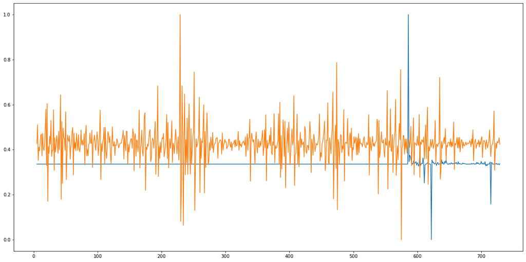

```python
plt.figure(figsize = (20,10))
plt.plot(min_max_scailing(series_data['currentActive_diff']))
plt.plot(min_max_scailing(series_data['initTotalKRW_diff']))
```

- iniTotalKRW가 currentActive를 인과한다는 상식과는 반하는 결론이 나왔다.
- 그래프를 그려본 결과, 이는 initTotalKRW의 진동에서 기인한 가성 관계인것처럼 보인다.

##### 시계열 분해

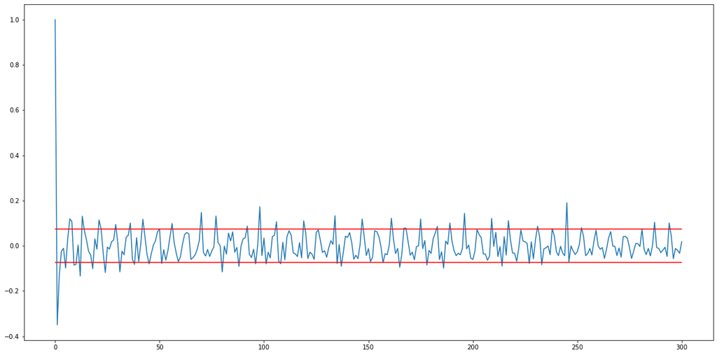

```python
plt.figure(figsize = (20,10))
plt.plot(sm.tsa.acf(series_data['initTotalKRW_diff'], nlags = 300))
plt.hlines(2/np.sqrt(len(series_data)), xmin = 0, xmax = 300, color = 'red')
plt.hlines(-2/np.sqrt(len(series_data)), xmin = 0, xmax = 300, color = 'red')
```

- acf 그래프를 확인해본 결과, 대략 7일 주기로 증감이 반복되는 싸이클이 보인다.
- 이 계절성을 통제한다.

```python
decomp = sm.tsa.STL(series_data['initTotalKRW_diff'], period = 7).fit()
```

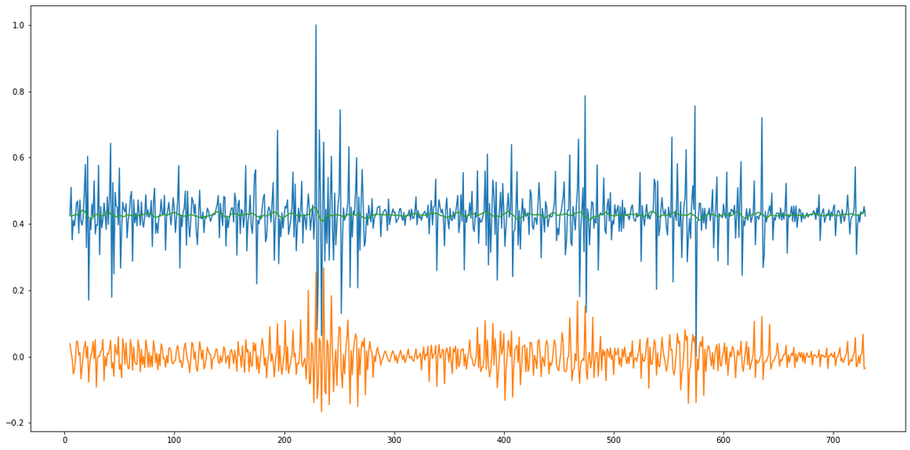

```python
plt.figure(figsize = (20,10))
plt.plot(series_data['initTotalKRW_diff'])
plt.plot(decomp.seasonal)
plt.plot(decomp.trend)
```

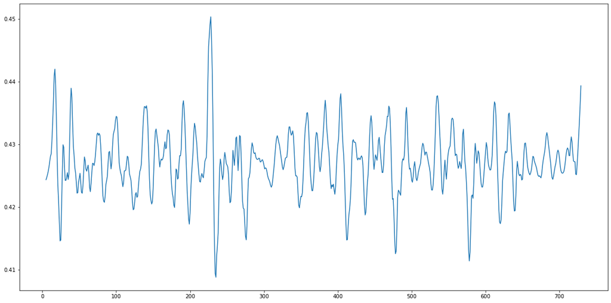

```python
plt.figure(figsize = (20,10))
plt.plot(decomp.trend)
```

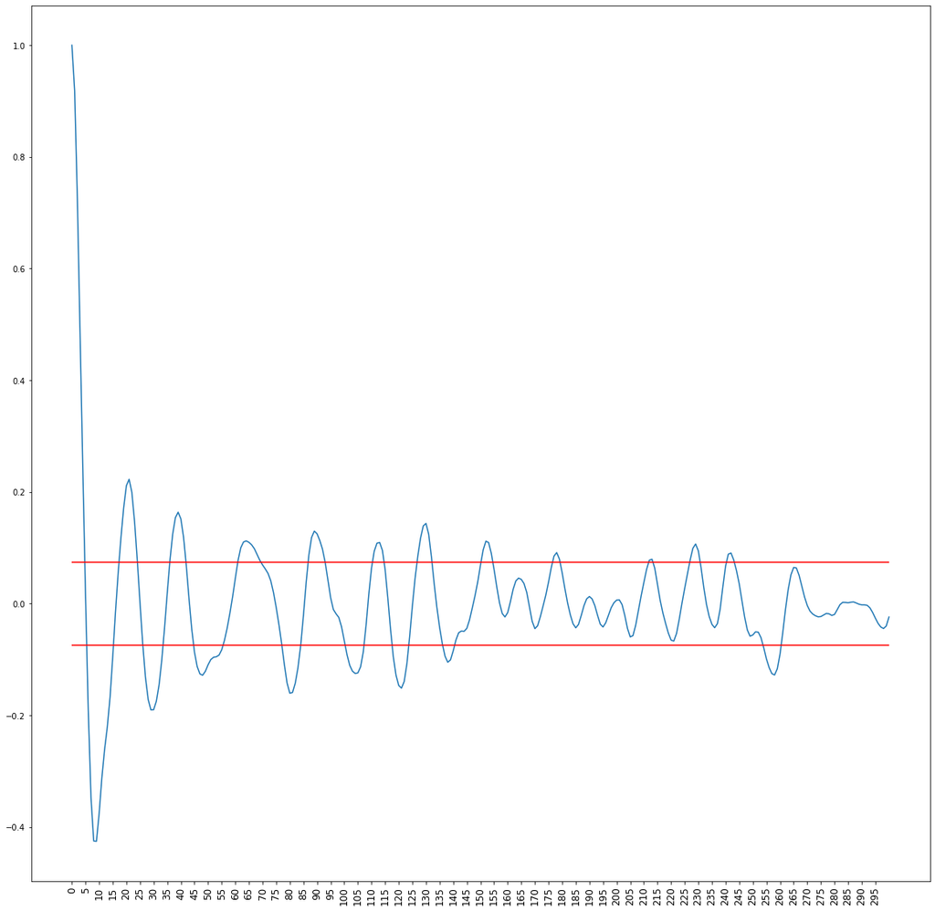

```python
plt.figure(figsize = (20,20))
plt.plot(sm.tsa.acf(decomp.trend, nlags = 300))
plt.hlines(2/np.sqrt(len(series_data)), xmin = 0, xmax = 300, color = 'red')
plt.hlines(-2/np.sqrt(len(series_data)), xmin = 0, xmax = 300, color = 'red')
plt.xticks([i for i in range(0,300, 5)], rotation = 90, size = 'large')
plt.show()
```

- 탈계절화가 완료된 시계열에 대하여 acf 그래프를 다시 확인해본결과, 15일마다 반복되는 싸이클이 존재한다.
- 이도 탈계절화한다.

```python
decomp_2 = sm.tsa.STL(decomp.trend, period = 15).fit()
```

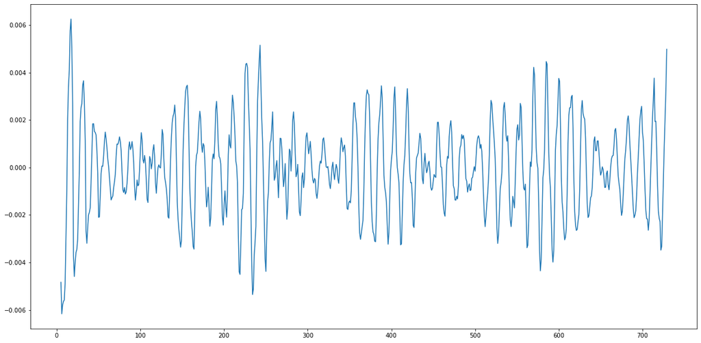

```python
plt.figure(figsize = (20,10))
plt.plot(decomp_2.seasonal)
```

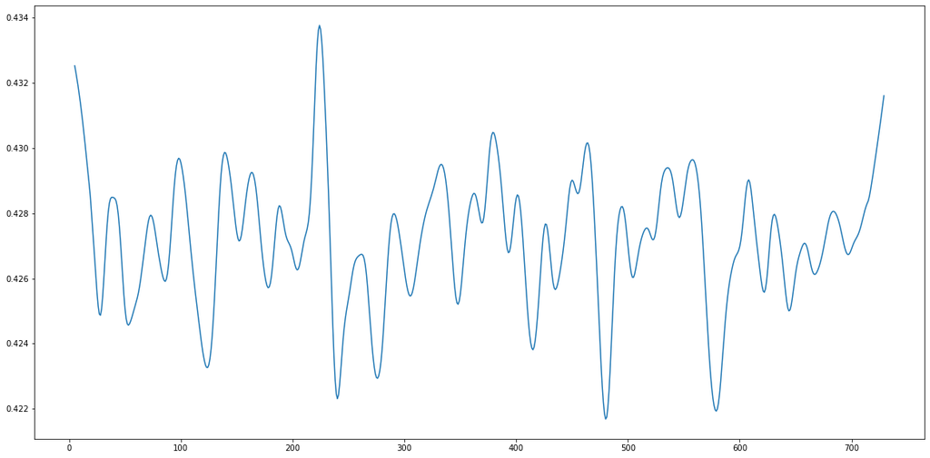

```python
plt.figure(figsize = (20,10))
plt.plot(decomp_2.trend)
```

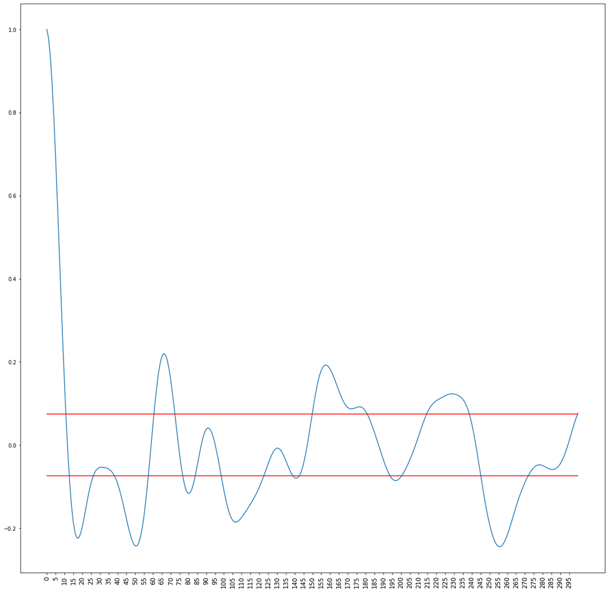

```python
plt.figure(figsize = (20,20))
plt.plot(sm.tsa.acf(decomp_2.trend, nlags = 300))
plt.hlines(2/np.sqrt(len(series_data)), xmin = 0, xmax = 300, color = 'red')
plt.hlines(-2/np.sqrt(len(series_data)), xmin = 0, xmax = 300, color = 'red')
plt.xticks([i for i in range(0,300, 5)], rotation = 90, size = 'large')
plt.show()
```

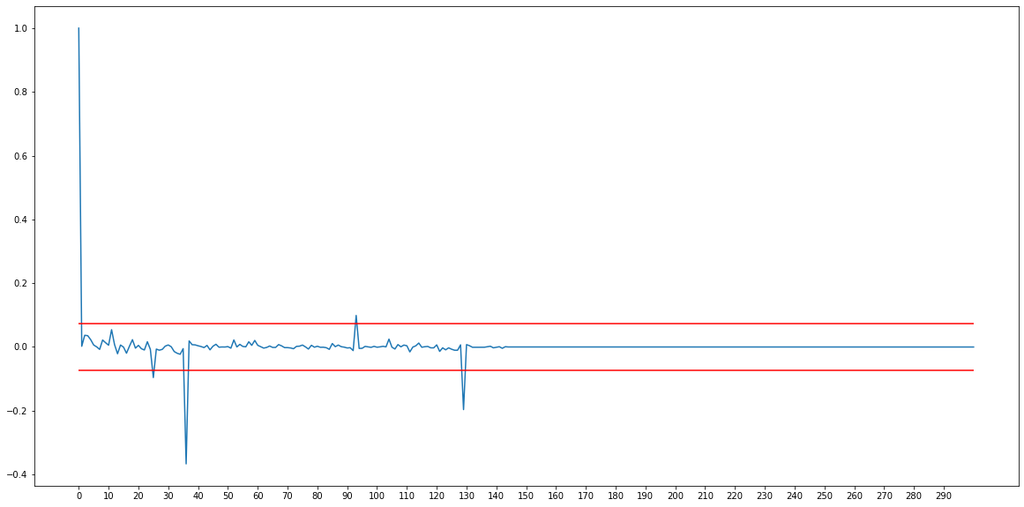

```python
plt.figure(figsize = (20,10))
plt.plot(sm.tsa.acf(series_data['currentActive_diff'], nlags = 300))
plt.hlines(2/np.sqrt(len(series_data)), xmin = 0, xmax = 300, color = 'red')
plt.hlines(-2/np.sqrt(len(series_data)), xmin = 0, xmax = 300, color = 'red')
plt.xticks([i for i in range(0, 300, 10)])
plt.show()
```

- 멤버십 가입자수의 경우, 뚜렷하게 패턴화한 싸이클은 딱히 보이지 않는다.
- 계절성을 발라낸 데이터로 그래인저 인과성검정을 다시 시도한다.

```python
series_data['initTotalKRW_trend'] = decomp_2.trend
```

```python
series_data['initTotalKRW_trend_diff'] = min_max_scailing(series_data['initTotalKRW_trend'].diff().fillna(0))
```

```python
sm.tsa.stattools.grangercausalitytests(series_data[['initTotalKRW_trend_diff', 'currentActive_diff']], 50)
```

```
Granger Causality
number of lags (no zero) 1
ssr based F test:         F=1.1431  , p=0.2854  , df_denom=721, df_num=1
ssr based chi2 test:   chi2=1.1478  , p=0.2840  , df=1
likelihood ratio test: chi2=1.1469  , p=0.2842  , df=1
parameter F test:         F=1.1431  , p=0.2854  , df_denom=721, df_num=1

Granger Causality
number of lags (no zero) 2
ssr based F test:         F=0.9480  , p=0.3880  , df_denom=718, df_num=2
ssr based chi2 test:   chi2=1.9092  , p=0.3850  , df=2
likelihood ratio test: chi2=1.9067  , p=0.3854  , df=2
parameter F test:         F=0.9480  , p=0.3880  , df_denom=718, df_num=2

Granger Causality
number of lags (no zero) 3
ssr based F test:         F=1.4294  , p=0.2329  , df_denom=715, df_num=3
ssr based chi2 test:   chi2=4.3302  , p=0.2279  , df=3
likelihood ratio test: chi2=4.3173  , p=0.2292  , df=3
parameter F test:         F=1.4294  , p=0.2329  , df_denom=715, df_num=3

Granger Causality
number of lags (no zero) 4
ssr based F test:         F=1.5341  , p=0.1905  , df_denom=712, df_num=4
ssr based chi2 test:   chi2=6.2139  , p=0.1837  , df=4
likelihood ratio test: chi2=6.1873  , p=0.1856  , df=4
parameter F test:         F=1.5341  , p=0.1905  , df_denom=712, df_num=4

Granger Causality
number of lags (no zero) 5
ssr based F test:         F=1.3733  , p=0.2322  , df_denom=709, df_num=5
ssr based chi2 test:   chi2=6.9729  , p=0.2227  , df=5
likelihood ratio test: chi2=6.9394  , p=0.2252  , df=5
parameter F test:         F=1.3733  , p=0.2322  , df_denom=709, df_num=5

Granger Causality
number of lags (no zero) 6
ssr based F test:         F=1.1055  , p=0.3574  , df_denom=706, df_num=6
ssr based chi2 test:   chi2=6.7550  , p=0.3441  , df=6
likelihood ratio test: chi2=6.7234  , p=0.3472  , df=6
```

[output cut: 294 more lines]

```
parameter F test:         F=1.0882  , p=0.3220  , df_denom=580, df_num=48

Granger Causality
number of lags (no zero) 49
ssr based F test:         F=0.9947  , p=0.4864  , df_denom=577, df_num=49
ssr based chi2 test:   chi2=57.1038 , p=0.1994  , df=49
likelihood ratio test: chi2=54.8197 , p=0.2634  , df=49
parameter F test:         F=0.9947  , p=0.4864  , df_denom=577, df_num=49

Granger Causality
number of lags (no zero) 50
ssr based F test:         F=0.9815  , p=0.5123  , df_denom=574, df_num=50
ssr based chi2 test:   chi2=57.7080 , p=0.2118  , df=50
likelihood ratio test: chi2=55.3733 , p=0.2792  , df=50
parameter F test:         F=0.9815  , p=0.5123  , df_denom=574, df_num=50
```

```
{1: ({'ssr_ftest': (1.1430809939313011, 0.28536004461896375, 721.0, 1),
   'ssr_chi2test': (1.147837225528796, 0.28400235208773644, 1),
   'lrtest': (1.146928289479547, 0.2841930905395328, 1),
   'params_ftest': (1.14308099393135, 0.28536004461896375, 721.0, 1.0)},
  [<statsmodels.regression.linear_model.RegressionResultsWrapper at 0x1788c186580>,
   <statsmodels.regression.linear_model.RegressionResultsWrapper at 0x1788c186520>,
   array([[0., 1., 0.]])]),
 2: ({'ssr_ftest': (0.9480226445594917, 0.38799101098396427, 718.0, 2),
   'ssr_chi2test': (1.9092489471212049, 0.3849566788239811, 2),
   'lrtest': (1.906732469362396, 0.38544135113699485, 2),
   'params_ftest': (0.9480226445589169, 0.3879910109841811, 718.0, 2.0)},
  [<statsmodels.regression.linear_model.RegressionResultsWrapper at 0x1788c17f4f0>,
   <statsmodels.regression.linear_model.RegressionResultsWrapper at 0x1788bb38310>,
   array([[0., 0., 1., 0., 0.],
          [0., 0., 0., 1., 0.]])]),
 3: ({'ssr_ftest': (1.4294166581346166, 0.23292609376281986, 715.0, 3),
   'ssr_chi2test': (4.330232841286125, 0.22794226070030396, 3),
   'lrtest': (4.31729913005438, 0.22917727170774763, 3),
   'params_ftest': (1.429416658134741, 0.23292609376278325, 715.0, 3.0)},
  [<statsmodels.regression.linear_model.RegressionResultsWrapper at 0x1788b2942e0>,
   <statsmodels.regression.linear_model.RegressionResultsWrapper at 0x1788bb46190>,
   array([[0., 0., 0., 1., 0., 0., 0.],
          [0., 0., 0., 0., 1., 0., 0.],
          [0., 0., 0., 0., 0., 1., 0.]])]),
 4: ({'ssr_ftest': (1.5340953585152364, 0.19046029522528116, 712.0, 4),
   'ssr_chi2test': (6.213948053311717, 0.1837300871770446, 4),
   'lrtest': (6.187323423611815, 0.185588790174862, 4),
   'params_ftest': (1.5340953585146682, 0.19046029522543276, 712.0, 4.0)},
  [<statsmodels.regression.linear_model.RegressionResultsWrapper at 0x1788c242820>,
   <statsmodels.regression.linear_model.RegressionResultsWrapper at 0x1788c242af0>,
   array([[0., 0., 0., 0., 1., 0., 0., 0., 0.],
          [0., 0., 0., 0., 0., 1., 0., 0., 0.],
          [0., 0., 0., 0., 0., 0., 1., 0., 0.],
          [0., 0., 0., 0., 0., 0., 0., 1., 0.]])]),
 5: ({'ssr_ftest': (1.3732762435853034, 0.23220958524937454, 709.0, 5),
   'ssr_chi2test': (6.972911815101681, 0.2226626990507485, 5),
   'lrtest': (6.939363313741524, 0.22518913978249594, 5),
   'params_ftest': (1.3732762435846446, 0.23220958524963206, 709.0, 5.0)},
  [<statsmodels.regression.linear_model.RegressionResultsWrapper at 0x1788c226760>,
   <statsmodels.regression.linear_model.RegressionResultsWrapper at 0x1788bb598b0>,
```

[output cut: 1052 more lines]

```
          [0., 0., 0., ..., 1., 0., 0.],
          [0., 0., 0., ..., 0., 1., 0.]])]),
 50: ({'ssr_ftest': (0.98146357660907, 0.5123267605949369, 574.0, 50),
   'ssr_chi2test': (57.70800646438347, 0.21176076023085388, 50),
   'lrtest': (55.373339864416266, 0.2791518749684363, 50),
   'params_ftest': (0.9814635766100088, 0.5123267605931197, 574.0, 50.0)},
  [<statsmodels.regression.linear_model.RegressionResultsWrapper at 0x1788a3053a0>,
   <statsmodels.regression.linear_model.RegressionResultsWrapper at 0x1788a3052e0>,
   array([[0., 0., 0., ..., 0., 0., 0.],
          [0., 0., 0., ..., 0., 0., 0.],
          [0., 0., 0., ..., 0., 0., 0.],
          ...,
          [0., 0., 0., ..., 0., 0., 0.],
          [0., 0., 0., ..., 1., 0., 0.],
          [0., 0., 0., ..., 0., 1., 0.]])])}
```

currentActive => initTotalKRW

a = 0.05에서 lag = 19 에서 그레인저 인과성이 존재한다

```python
sm.tsa.stattools.grangercausalitytests(series_data[['currentActive_diff','initTotalKRW_trend_diff']], 50)
```

```
Granger Causality
number of lags (no zero) 1
ssr based F test:         F=2.9815  , p=0.0846  , df_denom=721, df_num=1
ssr based chi2 test:   chi2=2.9940  , p=0.0836  , df=1
likelihood ratio test: chi2=2.9878  , p=0.0839  , df=1
parameter F test:         F=2.9815  , p=0.0846  , df_denom=721, df_num=1

Granger Causality
number of lags (no zero) 2
ssr based F test:         F=1.4160  , p=0.2434  , df_denom=718, df_num=2
ssr based chi2 test:   chi2=2.8517  , p=0.2403  , df=2
likelihood ratio test: chi2=2.8461  , p=0.2410  , df=2
parameter F test:         F=1.4160  , p=0.2434  , df_denom=718, df_num=2

Granger Causality
number of lags (no zero) 3
ssr based F test:         F=1.1591  , p=0.3245  , df_denom=715, df_num=3
ssr based chi2 test:   chi2=3.5114  , p=0.3193  , df=3
likelihood ratio test: chi2=3.5029  , p=0.3204  , df=3
parameter F test:         F=1.1591  , p=0.3245  , df_denom=715, df_num=3

Granger Causality
number of lags (no zero) 4
ssr based F test:         F=0.8977  , p=0.4648  , df_denom=712, df_num=4
ssr based chi2 test:   chi2=3.6360  , p=0.4575  , df=4
likelihood ratio test: chi2=3.6269  , p=0.4589  , df=4
parameter F test:         F=0.8977  , p=0.4648  , df_denom=712, df_num=4

Granger Causality
number of lags (no zero) 5
ssr based F test:         F=0.7765  , p=0.5668  , df_denom=709, df_num=5
ssr based chi2 test:   chi2=3.9425  , p=0.5577  , df=5
likelihood ratio test: chi2=3.9318  , p=0.5593  , df=5
parameter F test:         F=0.7765  , p=0.5668  , df_denom=709, df_num=5

Granger Causality
number of lags (no zero) 6
ssr based F test:         F=0.7397  , p=0.6178  , df_denom=706, df_num=6
ssr based chi2 test:   chi2=4.5200  , p=0.6067  , df=6
likelihood ratio test: chi2=4.5059  , p=0.6086  , df=6
```

[output cut: 294 more lines]

```
parameter F test:         F=0.7531  , p=0.8890  , df_denom=580, df_num=48

Granger Causality
number of lags (no zero) 49
ssr based F test:         F=0.7591  , p=0.8847  , df_denom=577, df_num=49
ssr based chi2 test:   chi2=43.5794 , p=0.6919  , df=49
likelihood ratio test: chi2=42.2323 , p=0.7421  , df=49
parameter F test:         F=0.7591  , p=0.8847  , df_denom=577, df_num=49

Granger Causality
number of lags (no zero) 50
ssr based F test:         F=0.7504  , p=0.8967  , df_denom=574, df_num=50
ssr based chi2 test:   chi2=44.1205 , p=0.7072  , df=50
likelihood ratio test: chi2=42.7384 , p=0.7571  , df=50
parameter F test:         F=0.7504  , p=0.8967  , df_denom=574, df_num=50
```

```
{1: ({'ssr_ftest': (2.9815452995275153, 0.08464715867580522, 721.0, 1),
   'ssr_chi2test': (2.9939511745602236, 0.08357601437914136, 1),
   'lrtest': (2.987777757274671, 0.08389522674842748, 1),
   'params_ftest': (2.981545299527711, 0.08464715867579335, 721.0, 1.0)},
  [<statsmodels.regression.linear_model.RegressionResultsWrapper at 0x1788badf0d0>,
   <statsmodels.regression.linear_model.RegressionResultsWrapper at 0x1788a305220>,
   array([[0., 1., 0.]])]),
 2: ({'ssr_ftest': (1.4160032253841488, 0.24335889841247893, 718.0, 2),
   'ssr_chi2test': (2.8517279441580494, 0.24030076034901646, 2),
   'lrtest': (2.846118655747432, 0.24097566447463206, 2),
   'params_ftest': (1.416003225384122, 0.24335889841247893, 718.0, 2.0)},
  [<statsmodels.regression.linear_model.RegressionResultsWrapper at 0x1788a3056d0>,
   <statsmodels.regression.linear_model.RegressionResultsWrapper at 0x1788a305c10>,
   array([[0., 0., 1., 0., 0.],
          [0., 0., 0., 1., 0.]])]),
 3: ({'ssr_ftest': (1.1591202267659868, 0.3244962685912327, 715.0, 3),
   'ssr_chi2test': (3.511404770874304, 0.31928596990198455, 3),
   'lrtest': (3.502893599579693, 0.32038702451809553, 3),
   'params_ftest': (1.159120226764351, 0.32449626859189024, 715.0, 3.0)},
  [<statsmodels.regression.linear_model.RegressionResultsWrapper at 0x1788a305b80>,
   <statsmodels.regression.linear_model.RegressionResultsWrapper at 0x1788a305820>,
   array([[0., 0., 0., 1., 0., 0., 0.],
          [0., 0., 0., 0., 1., 0., 0.],
          [0., 0., 0., 0., 0., 1., 0.]])]),
 4: ({'ssr_ftest': (0.8976566719193876, 0.46482919130454414, 712.0, 4),
   'ssr_chi2test': (3.636013822774598, 0.4575006171398833, 4),
   'lrtest': (3.6268762942172543, 0.4588504808454651, 4),
   'params_ftest': (0.8976566719211903, 0.4648291913034631, 712.0, 4.0)},
  [<statsmodels.regression.linear_model.RegressionResultsWrapper at 0x1788a305eb0>,
   <statsmodels.regression.linear_model.RegressionResultsWrapper at 0x1788a305df0>,
   array([[0., 0., 0., 0., 1., 0., 0., 0., 0.],
          [0., 0., 0., 0., 0., 1., 0., 0., 0.],
          [0., 0., 0., 0., 0., 0., 1., 0., 0.],
          [0., 0., 0., 0., 0., 0., 0., 1., 0.]])]),
 5: ({'ssr_ftest': (0.7764581763394561, 0.566836668086562, 709.0, 5),
   'ssr_chi2test': (3.9425238855035856, 0.5577204926161893, 5),
   'lrtest': (3.93176903460062, 0.5592808529345131, 5),
   'params_ftest': (0.7764581763333567, 0.5668366680909984, 709.0, 5.0)},
  [<statsmodels.regression.linear_model.RegressionResultsWrapper at 0x1788a305fa0>,
   <statsmodels.regression.linear_model.RegressionResultsWrapper at 0x1788a30e250>,
```

[output cut: 1052 more lines]

```
          [0., 0., 0., ..., 1., 0., 0.],
          [0., 0., 0., ..., 0., 1., 0.]])]),
 50: ({'ssr_ftest': (0.7503748026305632, 0.8966681829008619, 574.0, 50),
   'ssr_chi2test': (44.12046966686674, 0.7072321831038372, 50),
   'lrtest': (42.73843804137596, 0.7571157200350842, 50),
   'params_ftest': (0.7503747743757776, 0.8966682128096866, 574.0, 50.0)},
  [<statsmodels.regression.linear_model.RegressionResultsWrapper at 0x1788a38c8b0>,
   <statsmodels.regression.linear_model.RegressionResultsWrapper at 0x1788a38c7c0>,
   array([[0., 0., 0., ..., 0., 0., 0.],
          [0., 0., 0., ..., 0., 0., 0.],
          [0., 0., 0., ..., 0., 0., 0.],
          ...,
          [0., 0., 0., ..., 0., 0., 0.],
          [0., 0., 0., ..., 1., 0., 0.],
          [0., 0., 0., ..., 0., 1., 0.]])])}
```

initTotalKRW => currentActive

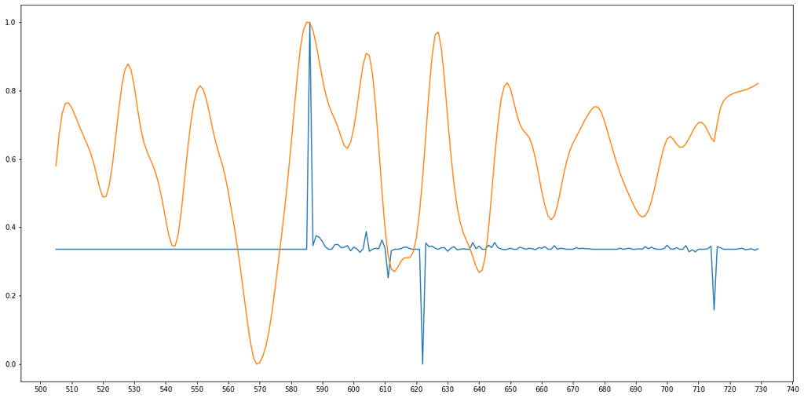

```python
plt.figure(figsize = (20,10))
plt.plot(min_max_scailing(series_data['currentActive_diff']).iloc[500:])
plt.plot(min_max_scailing(series_data['initTotalKRW_trend_diff'].iloc[500:]))
plt.xticks([i for i in range(500,750,10)])
plt.show()
```

- 양방향으로 인과성이 존재한다.
- initTotalKRW가 membership 가입 데이터에 영향을 끼친다는것이 이해가 되지 않는다.

#### 공적분 검정

공적분 관계에 있는 두 비정상 시계열이 선형결합을 통해 안정성을 가진다면 두 시계열은 공적분 관계에 있다고 한다.

비정상 시계열(차분 전 시계열)로 공적분 관계를 검정한다.

```python
sm.tsa.stattools.coint(series_data['currentActive'],
                       series_data['initTotalKRW_trend'])
```

```
(-1.0508077113545131,
 0.8927795800251623,
 array([-3.9116309 , -3.34458238, -3.0503132 ]))
```

- 두 시계열은 공적분 관계에 있지 않다.(p > 0.42)

#### CCF

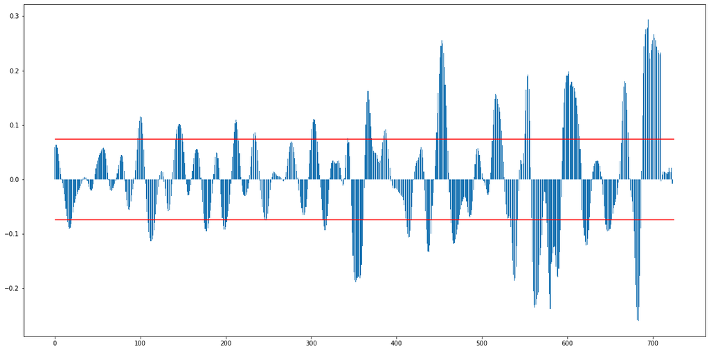

```python
plt.figure(figsize = (20,10))
plt.bar([i for i in range(len(series_data))],
            sm.tsa.stattools.ccf(series_data['currentActive_diff'], series_data['initTotalKRW_trend_diff']))
plt.hlines(2/np.sqrt(len(series_data)), xmin = 0, xmax = len(series_data), color = 'red')
plt.hlines(-2/np.sqrt(len(series_data)), xmin = 0, xmax = len(series_data), color = 'red')
```

- 차분을 했는데도 CCF도 수렴하지 않고 진동하고 있다.
- 사실상 교차상관관계를 도출하는것이 무의미하다.

#### VAR

- 앞에서 여러모로 EDA를 실시해본 결과는 사실 VAR을 적합해도 큰 의미가 없을 수준으로 두 시계열간에는 관계가 없다(혹은 왜곡되어있다)
- VAR은 X1.. XN의 확률변수가 각각 t1... ti의 시계열 값을 가지고 있는경우, 자기 자신은 물론이고 다른 확률변수(계)의 과거값까지 가져와서 OLS를 시도하는 방법론이다.
- 최소자승법(OLS) 등 전통적인 회귀분석의 계수 도출 방법론(알고리즘)을 사용하여 각 확률변수(계) 1 .... N에 계수 해당하는 행렬을 t1 ... ti에 해당하는 텐서만큼 확장하여 모델을 적합하게 된다.

```python
for i in range(0,30):
    var_model = sm.tsa.VAR(series_data[['currentActive_diff', 'initTotalKRW_trend_diff']].iloc[0 : -100])
    result = var_model.fit(i)
    print(i)
    print(result.aic)
    print(result.bic)
    print(result.fpe)
    print('--------')
```

```
0
-11.014817842052528
-11.00061703677337
1.645604227588745e-05
--------
1
-13.879727490310938
-13.837072198307386
9.37801676926789e-07
--------
2
-16.614776394128818
-16.543595872157912
6.08547655127576e-08
--------
3
-17.539502989208824
-17.439726202555534
2.413745415328521e-08
--------
4
-17.786397465765585
-17.65795308657911
1.8856778105136942e-08
--------
5
-17.882944004576366
-17.725760410194333
1.7121402346079065e-08
--------
6
-17.93280399404189
-17.746809265302314
1.6288742043714525e-08
--------
7
-17.926894927523904
-17.712016847064792
1.6385388320334436e-08
--------
```

[output cut: 95 more lines]

```
27
-21.750875409155825
-20.942689818964237
3.582346966609737e-10
--------
28
-22.139332748165025
-21.300675208924226
2.429498986827466e-10
--------
29
-22.194991635925085
-21.32578291325107
2.2982786321078075e-10
--------
```

[output not shown]

[output cut: 20 more lines]

```python
var_model = sm.tsa.VAR(series_data[['currentActive_diff', 'initTotalKRW_trend_diff']].iloc[0 : -100])
```

```python
result = var_model.fit(6)
```

```python
result.coefs
```

```
array([[[-2.13520145e-03,  5.80133405e-03],
        [-1.20236673e-03,  2.74611534e+00]],

       [[ 3.45653794e-02, -1.52432084e-01],
        [-2.32025283e-03, -2.46142282e+00]],

       [[ 3.41435919e-02,  3.21270078e-01],
        [ 4.76080733e-03,  3.58194174e-01]],

       [[ 2.16562071e-02, -7.17919451e-02],
        [ 1.01593637e-02,  4.45707701e-01]],

       [[ 4.02518242e-03, -2.14820269e-01],
        [ 8.97962919e-03,  2.74570710e-02]],

       [[-2.95938840e-03,  1.20311269e-01],
        [ 4.95855539e-03, -1.37216594e-01]]])
```

```python
result.summary()
```

```
  Summary of Regression Results
==================================
Model:                         VAR
Method:                        OLS
Date:           Mon, 24, Oct, 2022
Time:                     09:46:18
--------------------------------------------------------------------
No. of Equations:         2.00000    BIC:                   -17.7468
Nobs:                     619.000    HQIC:                  -17.8605
Log likelihood:           3819.56    FPE:                1.62887e-08
AIC:                     -17.9328    Det(Omega_mle):     1.56255e-08
--------------------------------------------------------------------
Results for equation currentActive_diff
=============================================================================================
                                coefficient       std. error           t-stat            prob
---------------------------------------------------------------------------------------------
const                              0.413675         0.043396            9.532           0.000
L1.currentActive_diff             -0.002135         0.040601           -0.053           0.958
L1.initTotalKRW_trend_diff         0.005801         0.194042            0.030           0.976
L2.currentActive_diff              0.034565         0.040591            0.852           0.394
L2.initTotalKRW_trend_diff        -0.152432         0.576560           -0.264           0.791
L3.currentActive_diff              0.034144         0.040602            0.841           0.400
L3.initTotalKRW_trend_diff         0.321270         0.756214            0.425           0.671
L4.currentActive_diff              0.021656         0.040605            0.533           0.594
L4.initTotalKRW_trend_diff        -0.071792         0.699415           -0.103           0.918
L5.currentActive_diff              0.004025         0.040646            0.099           0.921
L5.initTotalKRW_trend_diff        -0.214820         0.491251           -0.437           0.662
L6.currentActive_diff             -0.002959         0.040680           -0.073           0.942
L6.initTotalKRW_trend_diff         0.120311         0.163188            0.737           0.461
=============================================================================================

Results for equation initTotalKRW_trend_diff
=============================================================================================
                                coefficient       std. error           t-stat            prob
---------------------------------------------------------------------------------------------
const                             -0.000192         0.008795           -0.022           0.983
L1.currentActive_diff             -0.001202         0.008229           -0.146           0.884
L1.initTotalKRW_trend_diff         2.746115         0.039328           69.826           0.000
L2.currentActive_diff             -0.002320         0.008227           -0.282           0.778
L2.initTotalKRW_trend_diff        -2.461423         0.116856          -21.064           0.000
L3.currentActive_diff              0.004761         0.008229            0.579           0.563
L3.initTotalKRW_trend_diff         0.358194         0.153268            2.337           0.019
L4.currentActive_diff              0.010159         0.008230            1.234           0.217
L4.initTotalKRW_trend_diff         0.445708         0.141756            3.144           0.002
L5.currentActive_diff              0.008980         0.008238            1.090           0.276
L5.initTotalKRW_trend_diff         0.027457         0.099566            0.276           0.783
L6.currentActive_diff              0.004959         0.008245            0.601           0.548
L6.initTotalKRW_trend_diff        -0.137217         0.033075           -4.149           0.000
=============================================================================================

Correlation matrix of residuals
                           currentActive_diff  initTotalKRW_trend_diff
currentActive_diff                   1.000000                 0.016067
initTotalKRW_trend_diff              0.016067                 1.000000
```

- 예측값을 생성해본다.

```python
fore = result.forecast(series_data[['currentActive_diff', 'initTotalKRW_trend_diff']].iloc[-100:].values, 100)
```

```python
fore_0 = Series(fore.T[0])

fore_0.index = fore_0.index + series_data[0:-100].index.max()
```

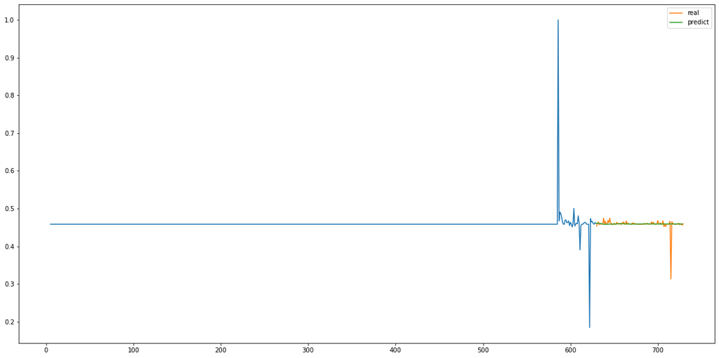

```python
plt.figure(figsize = (20,10))
plt.plot(series_data['currentActive_diff'].iloc[0:-100])
plt.plot(series_data[['currentActive_diff']].iloc[-100:], label = 'real')
plt.plot(fore_0, label = 'predict')
plt.legend()
```

```python
fore_1 = Series(fore.T[1])

fore_1.index = fore_1.index + series_data[0:-100].index.max()
```

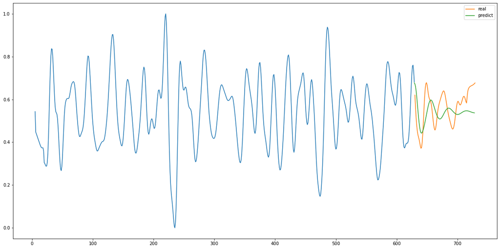

```python
plt.figure(figsize = (20,10))
plt.plot(series_data['initTotalKRW_trend_diff'].iloc[0:-100])
plt.plot(series_data[['initTotalKRW_trend_diff']].iloc[-100:], label = 'real')
plt.plot(fore_1, label = 'predict')
plt.legend()
```

- VAR 모델을 적합한 목적인 충격반응분석을 실시한다.
- 충격반응분석은 하나의 계(ex. initTotalKRW)에 1표준편차 충격이 가해졌을때 다른 계(ex. currentActive)에 몇 시차(lag)를 두고 영향이 극대화되는지 확인하는 분석 방법이다.

```python
np.sqrt(np.cov(np.array(result.resid.T)))
```

```
array([[0.02459376, 0.00140344],
       [0.00140344, 0.00498463]])
```

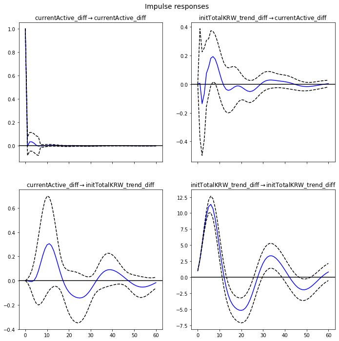

```python
result.irf(60).plot()
```

충격반응 분석 결과, initTotalKRW -> currentActive의 경우

## 결론

- 가설에 대한 결론은 다음과 같이 내릴 수 있다.
1. 그레인저 인과성 검정 결과, 주문액과 글로벌멤버십 증감은 상호간에 모두 영향을 미치고 있다.
2. 공적분검정 결과, 주문액과 글로벌멤버십은 서로 인과관계가 없다(공적분 관계가 없다)
3. VAR 모델을 적합한 결과 양방향 모두 5시차에서 부정적인 영향을 주고받다가, 10시차에서 긍정적인 영향을 주고받고 다시 0으로 수렴한다.

## reference

문권순, "벡터자기회귀(VAR)모형의 이해", 『통계분석연구』제2권 제1호(‘97.봄), 통계청(1997)

https://www.statsmodels.org/dev/vector_ar.html